# 01_Descriptive Statistics_Batch 191

**Descriptive Statistics**

```python
# IMPORT LIBRARIES
import numpy as np
import pandas as pd
import matplotlib.pyplot as plt
import seaborn as sns
import sidetable

# get the output for all commands
from IPython.core.interactiveshell import InteractiveShell
InteractiveShell.ast_node_interactivity = 'all'

# Ignore warnings
import warnings
warnings.filterwarnings('ignore')
```

```python
print(sns.get_dataset_names())
```

```
['anagrams', 'anscombe', 'attention', 'brain_networks', 'car_crashes', 'diamonds', 'dots', 'dowjones', 'exercise', 'flights', 'fmri', 'geyser', 'glue', 'healthexp', 'iris', 'mpg', 'penguins', 'planets', 'seaice', 'taxis', 'tips', 'titanic']
```

```python
taxi_df = sns.load_dataset('taxis')
```

```python
taxi_df.head()
```

|  | pickup | dropoff | passengers | distance | fare | tip | tolls | total | color | payment | pickup_zone | dropoff_zone | pickup_borough | dropoff_borough |
| --- | --- | --- | --- | --- | --- | --- | --- | --- | --- | --- | --- | --- | --- | --- |
| 0 | 2019-03-23 20:21:09 | 2019-03-23 20:27:24 | 1 | 1.60 | 7.0 | 2.15 | 0.0 | 12.95 | yellow | credit card | Lenox Hill West | UN/Turtle Bay South | Manhattan | Manhattan |
| 1 | 2019-03-04 16:11:55 | 2019-03-04 16:19:00 | 1 | 0.79 | 5.0 | 0.00 | 0.0 | 9.30 | yellow | cash | Upper West Side South | Upper West Side South | Manhattan | Manhattan |
| 2 | 2019-03-27 17:53:01 | 2019-03-27 18:00:25 | 1 | 1.37 | 7.5 | 2.36 | 0.0 | 14.16 | yellow | credit card | Alphabet City | West Village | Manhattan | Manhattan |
| 3 | 2019-03-10 01:23:59 | 2019-03-10 01:49:51 | 1 | 7.70 | 27.0 | 6.15 | 0.0 | 36.95 | yellow | credit card | Hudson Sq | Yorkville West | Manhattan | Manhattan |
| 4 | 2019-03-30 13:27:42 | 2019-03-30 13:37:14 | 3 | 2.16 | 9.0 | 1.10 | 0.0 | 13.40 | yellow | credit card | Midtown East | Yorkville West | Manhattan | Manhattan |

```python
taxi_df.info()
```

```
<class 'pandas.core.frame.DataFrame'>
RangeIndex: 6433 entries, 0 to 6432
Data columns (total 14 columns):
 #   Column           Non-Null Count  Dtype
---  ------           --------------  -----
 0   pickup           6433 non-null   datetime64[ns]
 1   dropoff          6433 non-null   datetime64[ns]
 2   passengers       6433 non-null   int64
 3   distance         6433 non-null   float64
 4   fare             6433 non-null   float64
 5   tip              6433 non-null   float64
 6   tolls            6433 non-null   float64
 7   total            6433 non-null   float64
 8   color            6433 non-null   object
 9   payment          6389 non-null   object
 10  pickup_zone      6407 non-null   object
 11  dropoff_zone     6388 non-null   object
 12  pickup_borough   6407 non-null   object
 13  dropoff_borough  6388 non-null   object
dtypes: datetime64[ns](2), float64(5), int64(1), object(6)
memory usage: 703.7+ KB
```

```python
taxi_df.stb.missing()
```

|  | missing | total | percent |
| --- | --- | --- | --- |
| dropoff_zone | 45 | 6433 | 0.699518 |
| dropoff_borough | 45 | 6433 | 0.699518 |
| payment | 44 | 6433 | 0.683973 |
| pickup_zone | 26 | 6433 | 0.404166 |
| pickup_borough | 26 | 6433 | 0.404166 |
| pickup | 0 | 6433 | 0.000000 |
| dropoff | 0 | 6433 | 0.000000 |
| passengers | 0 | 6433 | 0.000000 |
| distance | 0 | 6433 | 0.000000 |
| fare | 0 | 6433 | 0.000000 |
| tip | 0 | 6433 | 0.000000 |
| tolls | 0 | 6433 | 0.000000 |
| total | 0 | 6433 | 0.000000 |
| color | 0 | 6433 | 0.000000 |

## Measures of Central tendency

1. Mean
2. Median
3. Mode

### 1. Mean

```python
# mean of all columns
taxi_df.mean()
```

```
passengers     1.539251
distance       3.024617
fare          13.091073
tip            1.979220
tolls          0.325273
total         18.517794
dtype: float64
```

```python
# mean of a single column
taxi_df['fare'].mean()
```

```
13.091072594434944
```

### 2. Median

```python
taxi_df.median()
taxi_df['fare'].median()
```

```
passengers     1.00
distance       1.64
fare           9.50
tip            1.70
tolls          0.00
total         14.16
dtype: float64
```

```
9.5
```

### 3.Mode

```python
taxi_df.iloc[:, 2:].mode() # exclude first two columns
taxi_df['fare'].mode()
```

|  | passengers | distance | fare | tip | tolls | total | color | payment | pickup_zone | dropoff_zone | pickup_borough | dropoff_borough |
| --- | --- | --- | --- | --- | --- | --- | --- | --- | --- | --- | --- | --- |
| 0 | 1 | 0.8 | 7.5 | 0.0 | 0.0 | 9.3 | yellow | credit card | Midtown Center | Upper East Side North | Manhattan | Manhattan |

```
0    7.5
Name: fare, dtype: float64
```

## Measures of Variance/Spread

### 1. Range

```python
taxi_df.fare.max()
taxi_df.fare.min()

taxi_df.fare.max()-taxi_df.fare.min()
```

```
150.0
```

```
1.0
```

```
149.0
```

### 2. Variance

Variance is a measure of dispersion that takes into account the spread of all data points in a data set.

In simple words, the variance is a measure of how far a set of data are dispersed out from their mean or average value. It is denoted as $ \sigma^{2}$.

- It is always non-negative since each term in the variance sum is squared and therefore the result is either positive or zero.

### $ \sigma^2 = \frac{\displaystyle\sum_{i=1}^{n}(x_i - \bar{x})^2} {n-1} $

```python
### $ \sigma^2 = \frac{\displaystyle\sum_{i=1}^{n}(x_i - \bar{x})^2} {n-1} $
```

```python
# compare the variance of distance vs num of passengers

taxi_df.passengers.value_counts()

# three passenger
taxi_df[taxi_df.passengers == 3]['distance'].var()
taxi_df[taxi_df.passengers == 3]['distance'].mean()


# 5 passengers
taxi_df[taxi_df.passengers ==5]['distance'].var()
taxi_df[taxi_df.passengers ==5]['distance'].mean()
```

```
1    4678
2     876
5     277
3     243
6     153
4     110
0      96
Name: passengers, dtype: int64
```

```
15.498491330816577
```

```
3.135843621399177
```

```
12.454580950138643
```

```
2.9641877256317697
```

#### Variance of distance travelled with 5 passengers is less compared to 3 passengers.

### Why do we square the deviation ($x-\mu$)?

```python
df = pd.DataFrame()
```

```python
df['dist'] = taxi_df[taxi_df.passengers == 4].reset_index()['distance']
```

```python
df['mu'] =  df.dist.mean()
```

```python
df['x-mu'] = df.dist-df.mu
```

```python
df
```

|  | dist | mu | x-mu |
| --- | --- | --- | --- |
| 0 | 1.89 | 2.936455 | -1.046455 |
| 1 | 0.71 | 2.936455 | -2.226455 |
| 2 | 1.02 | 2.936455 | -1.916455 |
| 3 | 0.43 | 2.936455 | -2.506455 |
| 4 | 2.42 | 2.936455 | -0.516455 |
| ... | ... | ... | ... |
| 105 | 4.86 | 2.936455 | 1.923545 |
| 106 | 19.16 | 2.936455 | 16.223545 |
| 107 | 1.11 | 2.936455 | -1.826455 |
| 108 | 1.37 | 2.936455 | -1.566455 |
| 109 | 4.07 | 2.936455 | 1.133545 |

110 rows × 3 columns

```python
round(df['x-mu'].sum()) # the deviation from mean generates values which will cancel out each other
```

```
0
```

```python
df['x-mu_sq'] = df['x-mu']**2
```

```python
df['x-mu_sq'].sum()/(len(df)-1)
```

```
12.539237773144286
```

```python
df.dist.var()
```

```
12.539237773144288
```

### 3. Standard deviation

Standard deviation is the spread of a group of numbers from the mean.

### $ \sigma = \sqrt \frac{\displaystyle\sum_{i=1}^{n}(x_i - \mu)^2} {n-1} $

```python
# three passenger
taxi_df[taxi_df.passengers == 3]['distance'].var()
taxi_df[taxi_df.passengers == 3]['distance'].std()


# 5 passengers
taxi_df[taxi_df.passengers ==5]['distance'].var()
taxi_df[taxi_df.passengers ==5]['distance'].std()
```

```
15.498491330816577
```

```
3.9368123311654797
```

```
12.454580950138643
```

```
3.5291048369435902
```

### 4. IQR - Inter Quartile Range

```python
taxi_df.total.quantile(q=[0.25,0.5,0.75])
```

```
0.25    10.80
0.50    14.16
0.75    20.30
Name: total, dtype: float64
```

```python
(taxi_df.total<20.30).value_counts()

np.round(4806/len(taxi_df)*100)
```

```
True     4806
False    1627
Name: total, dtype: int64
```

```
75.0
```

```python
Q1, Q2, Q3 = tuple( taxi_df.total.quantile(q=[0.25,0.5,0.75]).values)
```

```python
Q1, Q2, Q3
```

```
(10.8, 14.16, 20.3)
```

```python
IQR = Q3-Q1

UL = Q3 + 1.5*IQR
LL = Q1- 1.5*IQR

print(IQR, UL, LL)
```

```
9.5 34.55 -3.4499999999999993
```

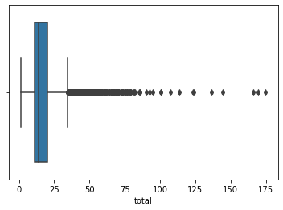

```python
sns.boxplot(x = taxi_df.total);
```

## Measures of Shape

### 1. Skewness

Skewness refers to a distortion or asymmetry that deviates from the symmetrical bell curve, or normal distribution, in a set of data. If the curve is shifted to the left or to the right, it is said to be skewed.

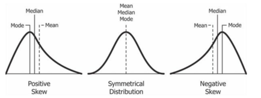

- Less than -1 or greater than 1, then the distribution is highly skewed.
- Between -1 and -0.5 or 0.5 and 1, then the distribution is moderately skewed.
- Between -0.5 and 0.5, then the distribution is approx. symmetric.

```python
taxi_df.skew()
```

```
passengers    2.359143
distance      3.008206
fare          3.217463
tip           2.665152
tolls         5.074936
total         3.093333
dtype: float64
```

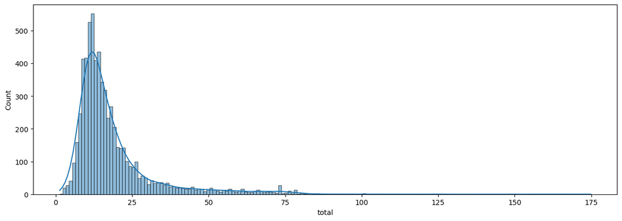

```python
plt.figure(figsize=(15,5), dpi = 100)
sns.histplot(taxi_df.total, kde = True);
```

### 2. Kurtosis

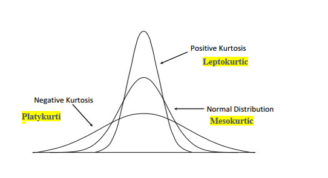

- Kurtosis tells you the height and sharpness if the central peak.
- A normal distribution will have kurtosis value exactly 3. It is called as **Mesokurtic**.
- A distribution with kurtosis <3 is called **Platykurtic**. Compared to a Normal distribution, the tails are shorter and central peak is lower and broader.
- A distribution with kurtosis >3 is called as **Leptokurtic**, where tails are longer and central peak is taller and sharper.

```python
taxi_df.kurt()
```

```
passengers     4.886070
distance      11.144464
fare          17.663376
tip           12.750449
tolls         35.470566
total         15.065717
dtype: float64
```

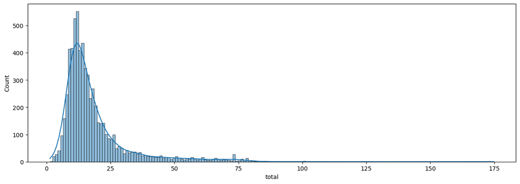

```python
plt.figure(figsize=(15,5), dpi = 100)
sns.histplot(taxi_df.total, kde = True);
```

```python
arr1 = np.random.randint(10,101,1000)
arr2 = np.random.randint(40,71,1000)
```

```python
# calculate Range
arr1.max()-arr1.min()
arr2.max()-arr2.min()
```

```
90
```

```
30
```

```python
np.var(arr1)
np.var(arr2)
```

```
680.017776
```

```
84.681776
```

```python
np.std(arr1)
np.std(arr2)
```

```
26.077150457824185
```

```
9.202270154695524
```

```python
pd.Series(arr1).kurt()
pd.Series(arr2).kurt()
```

```
-1.2094471546005854
```

```
-1.24596848322792
```

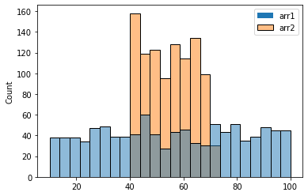

```python
sns.histplot([arr1, arr2])
plt.legend(['arr1','arr2']);
```

## Random Sampling

### Pandas Dataframe.sample()

```python
taxi_df.sample(n = 10,random_state=0)
```

|  | pickup | dropoff | passengers | distance | fare | tip | tolls | total | color | payment | pickup_zone | dropoff_zone | pickup_borough | dropoff_borough |
| --- | --- | --- | --- | --- | --- | --- | --- | --- | --- | --- | --- | --- | --- | --- |
| 3852 | 2019-03-26 16:21:11 | 2019-03-26 17:26:21 | 3 | 18.06 | 52.0 | 13.11 | 5.76 | 78.67 | yellow | credit card | JFK Airport | Times Sq/Theatre District | Queens | Manhattan |
| 3040 | 2019-03-06 12:39:48 | 2019-03-06 13:07:21 | 0 | 1.40 | 16.0 | 3.85 | 0.00 | 23.15 | yellow | credit card | Penn Station/Madison Sq West | Times Sq/Theatre District | Manhattan | Manhattan |
| 5196 | 2019-03-09 19:07:42 | 2019-03-09 19:12:27 | 2 | 1.27 | 6.0 | 0.00 | 0.00 | 9.30 | yellow | cash | Lincoln Square East | Upper West Side North | Manhattan | Manhattan |
| 2217 | 2019-03-04 07:07:14 | 2019-03-04 07:11:15 | 1 | 0.69 | 5.0 | 2.08 | 0.00 | 10.38 | yellow | credit card | Upper East Side North | Upper East Side North | Manhattan | Manhattan |
| 2189 | 2019-03-07 21:12:21 | 2019-03-07 21:35:29 | 1 | 3.77 | 17.0 | 4.16 | 0.00 | 24.96 | yellow | credit card | Gramercy | Yorkville West | Manhattan | Manhattan |
| 5511 | 2019-03-10 00:26:12 | 2019-03-10 00:35:38 | 1 | 1.17 | 7.5 | 0.00 | 0.00 | 8.80 | green | cash | Crown Heights North | Clinton Hill | Brooklyn | Brooklyn |
| 3450 | 2019-03-13 09:30:53 | 2019-03-13 09:42:44 | 6 | 1.12 | 8.5 | 2.36 | 0.00 | 14.16 | yellow | credit card | Penn Station/Madison Sq West | Times Sq/Theatre District | Manhattan | Manhattan |
| 202 | 2019-03-15 21:25:04 | 2019-03-15 21:31:55 | 1 | 0.88 | 6.0 | 0.00 | 0.00 | 9.80 | yellow | cash | Upper East Side South | Midtown Center | Manhattan | Manhattan |
| 5722 | 2019-03-24 05:42:58 | 2019-03-24 06:07:17 | 1 | 6.87 | 24.0 | 0.00 | 0.00 | 25.30 | green | cash | Washington Heights South | Van Cortlandt Village | Manhattan | Bronx |
| 842 | 2019-03-29 10:36:53 | 2019-03-29 10:48:38 | 1 | 1.19 | 8.5 | 2.36 | 0.00 | 14.16 | yellow | credit card | West Village | Gramercy | Manhattan | Manhattan |

### sklearn - train_test_split

```python
from sklearn.model_selection import train_test_split
```

```python
taxi_df.shape
```

```
(6433, 14)
```

```python
# split the dataset randomly into train and test datasets
traindata, testdata = train_test_split(taxi_df, random_state=111, test_size=0.3)
```

```python
traindata.shape
testdata.shape
```

```
(4503, 14)
```

```
(1930, 14)
```

```python
4503/6433
1930/6433
```

```
0.6999844551531167
```

```
0.30001554484688325
```

```python
traindata.head()
testdata.head()
```

|  | pickup | dropoff | passengers | distance | fare | tip | tolls | total | color | payment | pickup_zone | dropoff_zone | pickup_borough | dropoff_borough |
| --- | --- | --- | --- | --- | --- | --- | --- | --- | --- | --- | --- | --- | --- | --- |
| 1220 | 2019-03-01 07:25:29 | 2019-03-01 07:37:21 | 0 | 3.10 | 11.5 | 3.65 | 0.00 | 15.95 | yellow | credit card | Hamilton Heights | Manhattan Valley | Manhattan | Manhattan |
| 2865 | 2019-03-15 10:45:49 | 2019-03-15 11:01:14 | 1 | 1.38 | 11.0 | 2.86 | 0.00 | 17.16 | yellow | credit card | West Chelsea/Hudson Yards | Times Sq/Theatre District | Manhattan | Manhattan |
| 5997 | 2019-03-02 02:56:23 | 2019-03-02 03:24:37 | 1 | 6.81 | 24.0 | 0.00 | 0.00 | 25.30 | green | cash | Jackson Heights | Queensboro Hill | Queens | Queens |
| 2685 | 2019-03-08 11:35:03 | 2019-03-08 12:06:30 | 5 | 8.74 | 29.5 | 7.71 | 5.76 | 46.27 | yellow | credit card | LaGuardia Airport | Upper East Side North | Queens | Manhattan |
| 3928 | 2019-03-07 23:47:25 | 2019-03-07 23:59:02 | 3 | 2.30 | 10.5 | 2.86 | 0.00 | 17.16 | yellow | credit card | Lincoln Square East | Yorkville West | Manhattan | Manhattan |

|  | pickup | dropoff | passengers | distance | fare | tip | tolls | total | color | payment | pickup_zone | dropoff_zone | pickup_borough | dropoff_borough |
| --- | --- | --- | --- | --- | --- | --- | --- | --- | --- | --- | --- | --- | --- | --- |
| 1779 | 2019-03-11 22:00:46 | 2019-03-11 22:17:59 | 3 | 3.11 | 14.0 | 3.56 | 0.0 | 21.36 | yellow | credit card | Midtown Center | Upper West Side North | Manhattan | Manhattan |
| 4465 | 2019-03-26 19:18:00 | 2019-03-26 19:22:14 | 1 | 0.75 | 5.0 | 1.86 | 0.0 | 11.16 | yellow | credit card | Lenox Hill West | Upper East Side North | Manhattan | Manhattan |
| 5759 | 2019-03-02 11:06:52 | 2019-03-02 11:08:29 | 1 | 0.51 | 3.5 | 1.08 | 0.0 | 5.38 | green | credit card | East Harlem North | East Harlem North | Manhattan | Manhattan |
| 5064 | 2019-03-08 12:49:56 | 2019-03-08 12:57:00 | 1 | 1.00 | 6.0 | 2.75 | 0.0 | 12.05 | yellow | credit card | Midtown East | Midtown North | Manhattan | Manhattan |
| 4683 | 2019-03-15 16:16:21 | 2019-03-15 16:30:14 | 1 | 1.02 | 9.5 | 2.07 | 0.0 | 15.87 | yellow | credit card | SoHo | Lower East Side | Manhattan | Manhattan |